# Final Project

Alex Radecki

August 4th, 2023

# Setup and Data Import

```r
library(tidyverse)
library(stringr)
library(lubridate)
library(skimr)
library(ggpubr)
library(readr)
library(flextable)
library(dplyr)
library(magrittr)
library(gtrendsR)
library(knitr)
library(ggplot2)
library(patchwork)
library(sf)
library(mapview)
library(leaflet)
```

**Importing data into R**

```r
gunViolence <- read.csv("stage3.csv")
```

**Creating new variables**

```r
# Year
gunViolence <- gunViolence %>% mutate(year = as.numeric(substr(date, 1, 4)))

# Month
gunViolence <- gunViolence %>% mutate(month = as.numeric(substr(date, 6, 7)))

# Day
gunViolence <- gunViolence %>% mutate(day = as.numeric(substr(date, 9, 10)))

# Combined number of killed and injured
gunViolence <- gunViolence %>% mutate(n_totalKilledInjured = n_killed + n_injured)

# Creating variable representing whether incident resulted in injury, death, or both
resultFun <- function(injured, killed) {
  if(injured > 0 && killed < 1) {
    return("Injury")
  }
  else if(injured < 1 && killed > 0) {
    return("Death")
  }
  else if(injured > 0 && killed > 0) {
    return("Injury and Death")
  }
  else {
    return("No Injury or Death")
  }
}

gunViolence <- gunViolence %>% mutate(incidentResult = mapply(resultFun, n_injured, n_killed))
```

**Changing full state name to abbreviation**

```r
library(qdap)

gunViolence <- gunViolence %>% mutate(state = mgsub(state.name, state.abb, state))
gunViolence <- gunViolence %>% mutate(state = str_to_upper(state))
```

**Creating data frame with corresponding month name and combining it with gun violence data set using left join**

```r
# Creating a table storing the month name for the corresponding month number
month <- 1:12
monthNames <- c("January", "February", "March", "April", "May", "June", "July",
                "August", "September", "October", "November", "December")

monthsAndNames <- tibble(month, monthNames)
```

```r
gunViolenceMonthNames <- gunViolence %>% left_join(monthsAndNames, by = c("month" = "month"))
```

**Exploring high-level characteristics of data**

```r
glimpse(gunViolenceMonthNames)
```

```
## Rows: 239,677
## Columns: 35
## $ incident_id                 <int> 461105, 460726, 478855, 478925, 478959, 47…
## $ date                        <chr> "2013-01-01", "2013-01-01", "2013-01-01", …
## $ state                       <chr> "PA", "CA", "OH", "CO", "NC", "OK", "NM", …
## $ city_or_county              <chr> "Mckeesport", "Hawthorne", "Lorain", "Auro…
## $ address                     <chr> "1506 Versailles Avenue and Coursin Street…
## $ n_killed                    <int> 0, 1, 1, 4, 2, 4, 5, 0, 0, 1, 1, 1, 2, 0, …
## $ n_injured                   <int> 4, 3, 3, 0, 2, 0, 0, 5, 4, 6, 3, 3, 3, 5, …
## $ incident_url                <chr> "http://www.gunviolencearchive.org/inciden…
## $ source_url                  <chr> "http://www.post-gazette.com/local/south/2…
## $ incident_url_fields_missing <chr> "False", "False", "False", "False", "False…
## $ congressional_district      <int> 14, 43, 9, 6, 6, 1, 1, 2, 9, 7, 3, 1, 3, 1…
## $ gun_stolen                  <chr> "", "", "0::Unknown||1::Unknown", "", "0::…
## $ gun_type                    <chr> "", "", "0::Unknown||1::Unknown", "", "0::…
```

[output cut: 22 more lines]

```r
skim(gunViolenceMonthNames)
```

Data summary

| Name | gunViolenceMonthNames |
| --- | --- |
| Number of rows | 239677 |
| Number of columns | 35 |
| _______________________ |  |
| Column type frequency: |  |
| character | 22 |
| numeric | 13 |
| ________________________ |  |
| Group variables | None |

**Variable type: character**

| skim_variable | n_missing | complete_rate | min | max | empty | n_unique | whitespace |
| --- | --- | --- | --- | --- | --- | --- | --- |
| date | 0 | 1 | 10 | 10 | 0 | 1725 | 0 |
| state | 0 | 1 | 2 | 20 | 0 | 51 | 0 |
| city_or_county | 0 | 1 | 3 | 46 | 0 | 12898 | 0 |
| address | 0 | 1 | 0 | 97 | 16497 | 198038 | 0 |
| incident_url | 0 | 1 | 48 | 50 | 0 | 239677 | 0 |
| source_url | 0 | 1 | 0 | 255 | 468 | 213990 | 0 |
| incident_url_fields_missing | 0 | 1 | 5 | 5 | 0 | 1 | 0 |
| gun_stolen | 0 | 1 | 0 | 5488 | 99498 | 350 | 0 |
| gun_type | 0 | 1 | 0 | 5488 | 99451 | 2503 | 0 |
| incident_characteristics | 0 | 1 | 0 | 761 | 326 | 18127 | 0 |
| location_description | 0 | 1 | 0 | 100 | 197588 | 27596 | 0 |
| notes | 0 | 1 | 0 | 256 | 81017 | 136653 | 0 |
| participant_age | 0 | 1 | 0 | 517 | 92298 | 18952 | 0 |
| participant_age_group | 0 | 1 | 0 | 1536 | 42119 | 899 | 0 |
| participant_gender | 0 | 1 | 0 | 803 | 36362 | 874 | 0 |
| participant_name | 0 | 1 | 0 | 2152 | 122253 | 113489 | 0 |
| participant_relationship | 0 | 1 | 0 | 366 | 223903 | 285 | 0 |
| participant_status | 0 | 1 | 0 | 1500 | 27626 | 2151 | 0 |
| participant_type | 0 | 1 | 0 | 1311 | 24863 | 260 | 0 |
| sources | 0 | 1 | 0 | 3015 | 609 | 217281 | 0 |
| incidentResult | 0 | 1 | 5 | 18 | 0 | 4 | 0 |
| monthNames | 0 | 1 | 3 | 9 | 0 | 12 | 0 |

**Variable type: numeric**

| skim_variable | n_missing | complete_rate | mean | sd | p0 | p25 | p50 | p75 | p100 | hist |
| --- | --- | --- | --- | --- | --- | --- | --- | --- | --- | --- |
| incident_id | 0 | 1.00 | 559334.35 | 293128.68 | 92114.00 | 308545.00 | 543587.00 | 817228.00 | 1083472.00 | ▇▇▆▆▆ |
| n_killed | 0 | 1.00 | 0.25 | 0.52 | 0.00 | 0.00 | 0.00 | 0.00 | 50.00 | ▇▁▁▁▁ |
| n_injured | 0 | 1.00 | 0.49 | 0.73 | 0.00 | 0.00 | 0.00 | 1.00 | 53.00 | ▇▁▁▁▁ |
| congressional_district | 11944 | 0.95 | 8.00 | 8.48 | 0.00 | 2.00 | 5.00 | 10.00 | 53.00 | ▇▂▁▁▁ |
| latitude | 7923 | 0.97 | 37.55 | 5.13 | 19.11 | 33.90 | 38.57 | 41.44 | 71.34 | ▁▇▅▁▁ |
| longitude | 7923 | 0.97 | -89.34 | 14.36 | -171.43 | -94.16 | -86.25 | -80.05 | 97.43 | ▁▇▁▁▁ |
| n_guns_involved | 99451 | 0.59 | 1.37 | 4.68 | 1.00 | 1.00 | 1.00 | 1.00 | 400.00 | ▇▁▁▁▁ |
| state_house_district | 38772 | 0.84 | 55.45 | 42.05 | 1.00 | 21.00 | 47.00 | 84.00 | 901.00 | ▇▁▁▁▁ |
| state_senate_district | 32335 | 0.87 | 20.48 | 14.20 | 1.00 | 9.00 | 19.00 | 30.00 | 94.00 | ▇▆▂▁▁ |
| year | 0 | 1.00 | 2015.71 | 1.23 | 2013.00 | 2015.00 | 2016.00 | 2017.00 | 2018.00 | ▇▇▇▇▂ |
| month | 0 | 1.00 | 6.35 | 3.45 | 1.00 | 3.00 | 6.00 | 9.00 | 12.00 | ▇▅▅▅▇ |
| day | 0 | 1.00 | 15.77 | 8.83 | 1.00 | 8.00 | 16.00 | 23.00 | 31.00 | ▇▇▇▇▆ |
| n_totalKilledInjured | 0 | 1.00 | 0.75 | 0.84 | 0.00 | 0.00 | 1.00 | 1.00 | 103.00 | ▇▁▁▁▁ |

# ggplot Visualizations

**Bar chart of the total number of gun violence deaths by state**

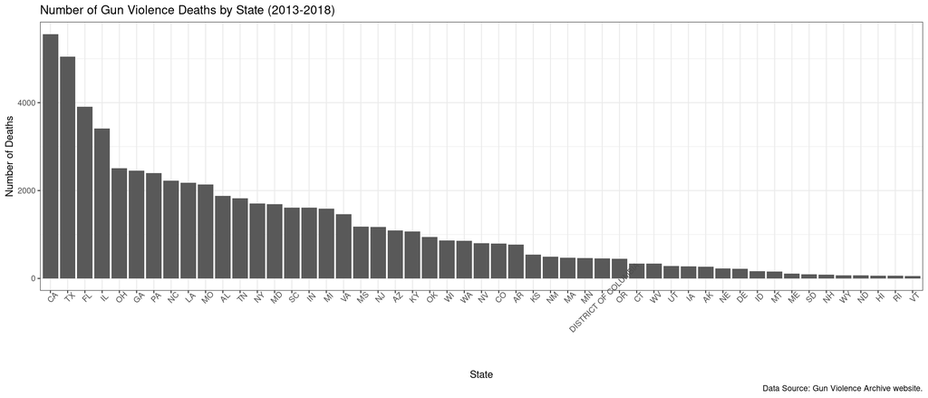

**Bar chart of the total number of gun violence deaths by month**

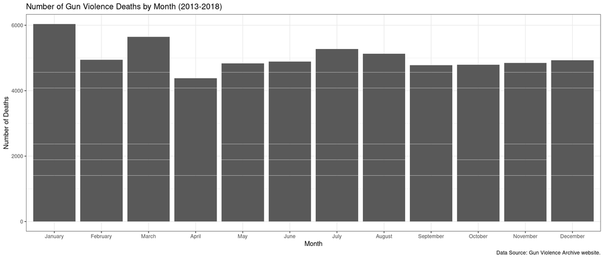

**Pie chart of the percentage of gun violence incidents resulting in injury, death, or both**

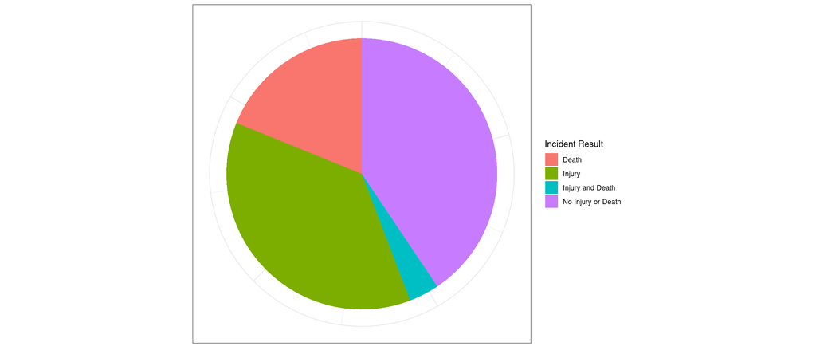

**Scatter plot of the number of injured by the number killed per gun violence incident**

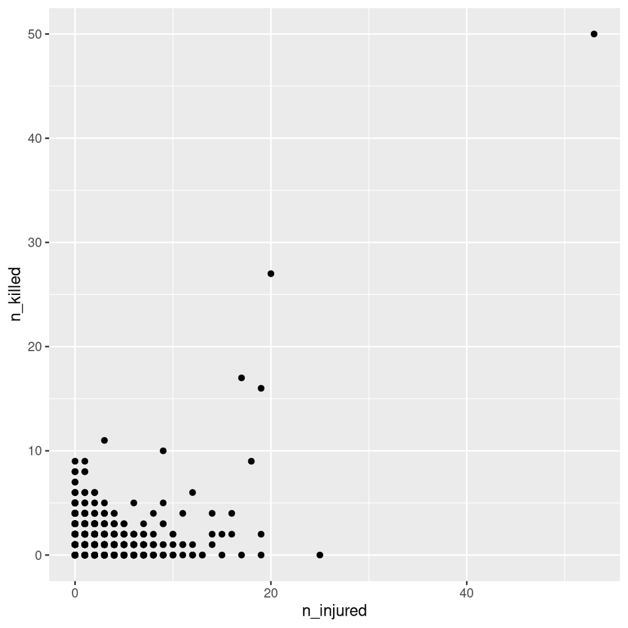

```r
gunViolence %>% ggplot(aes(x = n_injured,
                           y = n_killed)) +
  geom_point()
```

```r
quartiles <- quantile(gunViolence$n_totalKilledInjured, probs = c(0.25, 0.75))
IQR <- IQR(gunViolence$n_totalKilledInjured)

lowerQuartile <- quartiles[1] - 1.5 * IQR
upperQuartile <- quartiles[2] + 1.5 * IQR

gunViolenceNoOutlier <- subset(gunViolence, gunViolence$n_totalKilledInjured > lowerQuartile &
                                 gunViolence$n_totalKilledInjured < upperQuartile)
```

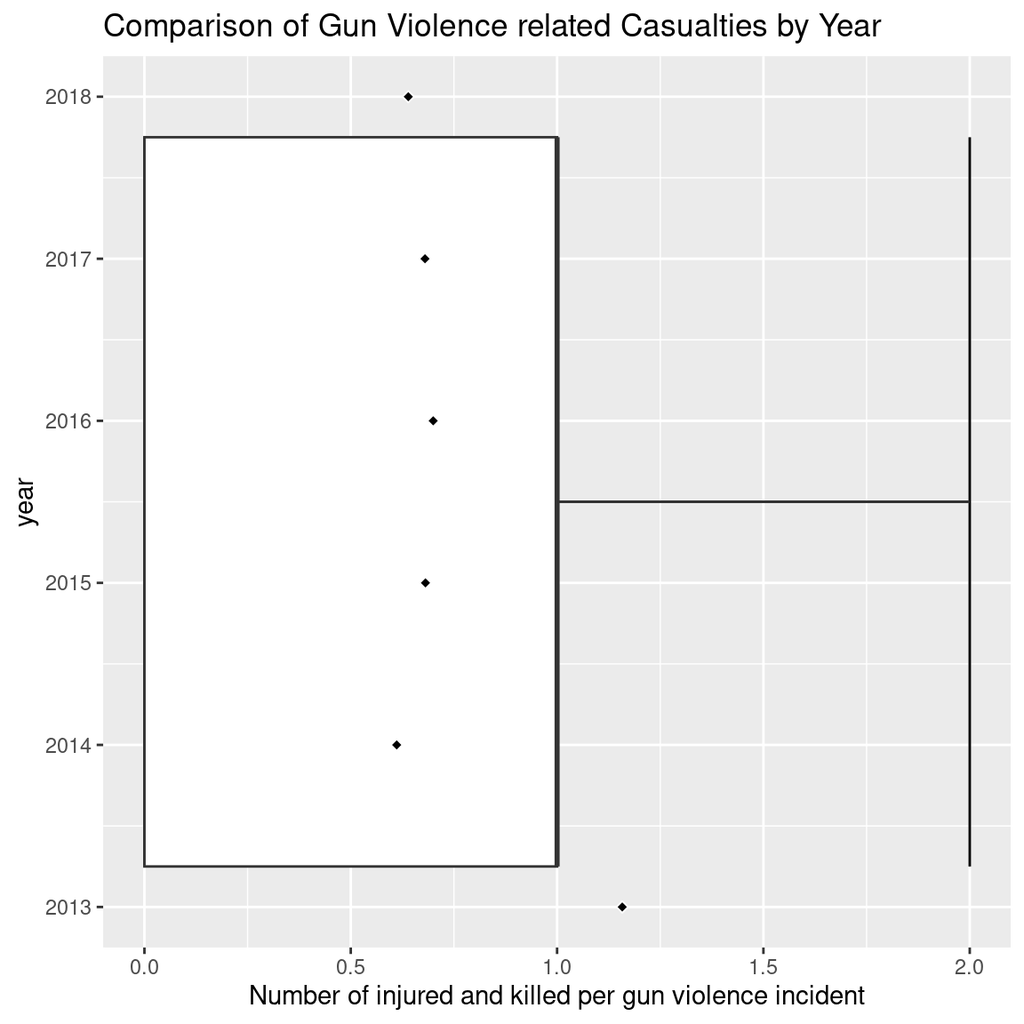

```r
gunViolenceNoOutlier %>% ggplot(aes(x = year, y = n_totalKilledInjured,
                         fill = year)) +
  stat_boxplot(geom = "errorbar", width = 0.2, coef = 1.5) +
  stat_boxplot(geom = "boxplot", width = 0.5, coef = 1.5,
               outlier.shape = 8) +
  stat_summary(fun = "mean", geom = "point", shape = 23, fill = "black",
               color = "white") +
  scale_fill_manual(values = c("#009E73", "#56B4E9")) +
    coord_flip() +
    labs(y = "Number of injured and killed per gun violence incident",
         title = "Comparison of Gun Violence related Casualties by Year") +
  theme(legend.position = "none")
```

**Line graph showing the number of searches for “shootings” between 2013 and 2018 with a line plot of casualties per shooting by date for reference**

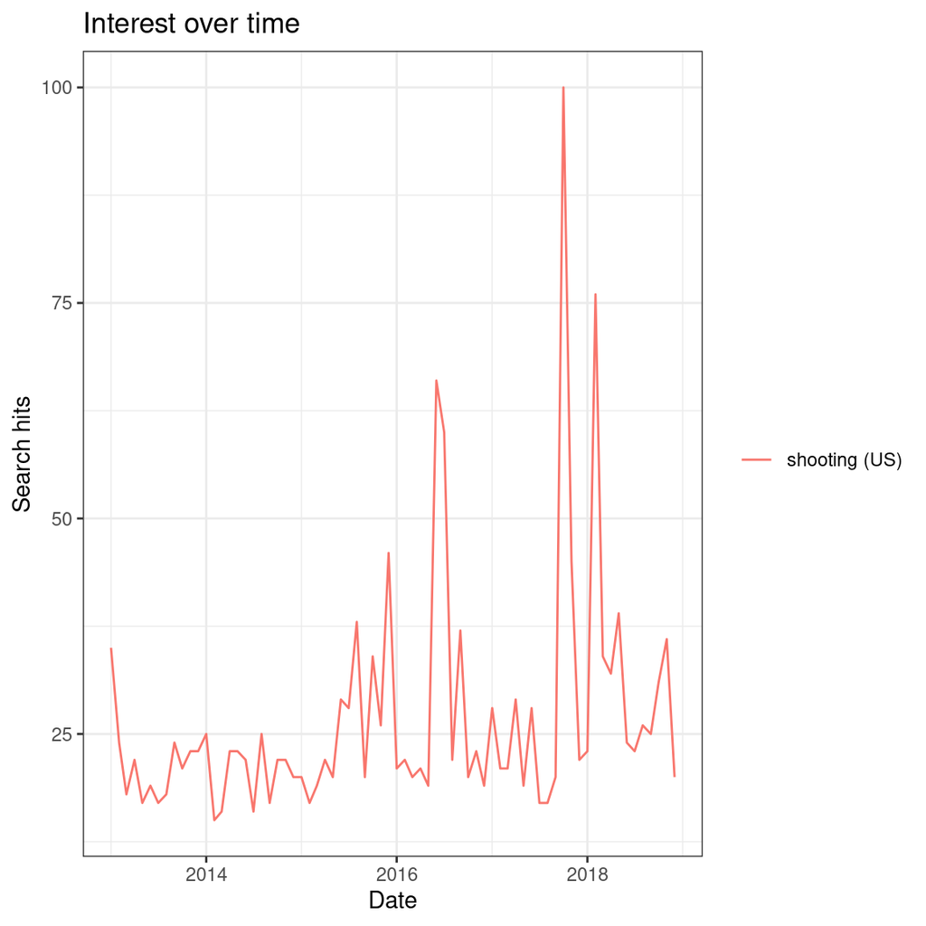

```r
gunViolence <- gunViolence %>% mutate(date = str_remove_all(date, "-"))

shootingSearches <- gtrends(c("shooting"), time = "2013-01-01 2018-12-31", geo = "US")
plot(shootingSearches)
```

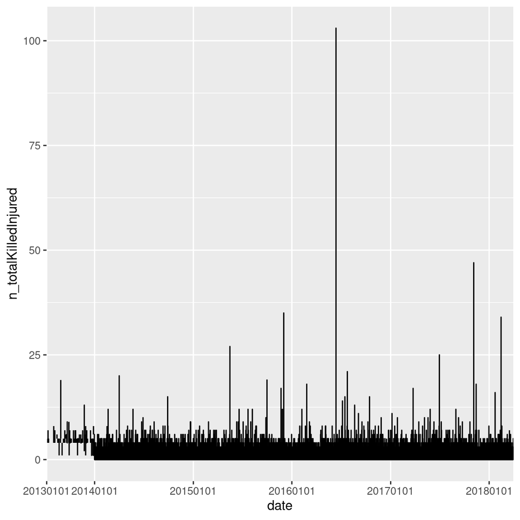

```r
gunViolence %>% ggplot(aes(x = date,
                           y = n_totalKilledInjured)) +
  geom_line() +
  scale_x_discrete(breaks = c("20130101", "20140101", "20150101",
                              "20160101", "20170101", "20180101"))
```

**Leaflet map of total number of injured and killed per mass shooting incident**

```r
library(leaflet.extras)

# Gun Violence Archive defines a mass shooting as four or more people shot or killed in a single incident
massShooting <- gunViolence %>% filter(n_totalKilledInjured > 4, na.rm = TRUE)

massShooting %>% leaflet() %>%
  addTiles() %>%
  addCircles(lng = massShooting$longitude,
             lat = massShooting$latitude,
             weight = 7,
             radius = massShooting$n_totalKilledInjured^2.5,
             popup = massShooting$date)
```

[interactive chart not shown]

# Summary Statistics

```r
gunViolence %>% group_by(month) %>%
  summarize(n = n(),
            averageTotalKilledInjuredMonth = (mean(n_totalKilledInjured)),
            totalSDMonth = sd(n_totalKilledInjured),
            na.rm = TRUE)
```

```
## # A tibble: 12 × 5
##    month     n averageTotalKilledInjuredMonth totalSDMonth na.rm
##    <dbl> <int>                          <dbl>        <dbl> <lgl>
##  1     1 23091                          0.735        0.769 TRUE
##  2     2 18841                          0.709        0.833 TRUE
##  3     3 22640                          0.712        0.792 TRUE
##  4     4 18628                          0.713        0.789 TRUE
##  5     5 19930                          0.756        0.826 TRUE
##  6     6 18755                          0.783        1.11  TRUE
##  7     7 21126                          0.783        0.854 TRUE
##  8     8 21040                          0.757        0.822 TRUE
##  9     9 19656                          0.740        0.818 TRUE
## 10    10 19890                          0.731        0.791 TRUE
## 11    11 17974                          0.775        0.883 TRUE
## 12    12 18106                          0.766        0.794 TRUE
```

```r
gunViolence %>% group_by(state) %>%
  summarize(n = n(),
            averageTotalKilledInjuredState = (mean(n_totalKilledInjured)),
            totalSDState = sd(n_totalKilledInjured),
            na.rm = TRUE)
```

```
## # A tibble: 51 × 5
##    state                    n averageTotalKilledInjuredState totalSDState na.rm
##    <chr>                <int>                          <dbl>        <dbl> <lgl>
##  1 AK                    1349                          0.439        0.658 TRUE
##  2 AL                    5471                          0.892        0.764 TRUE
##  3 AR                    2842                          0.746        0.896 TRUE
##  4 AZ                    2328                          0.941        0.815 TRUE
##  5 CA                   16306                          0.810        0.929 TRUE
##  6 CO                    3201                          0.603        0.769 TRUE
##  7 CT                    3067                          0.521        0.741 TRUE
##  8 DE                    1685                          0.635        0.691 TRUE
##  9 DISTRICT OF COLUMBIA  3195                          0.587        0.833 TRUE
## 10 FL                   15029                          0.731        1.23  TRUE
## # ℹ 41 more rows
```

# Monte Carlo Method

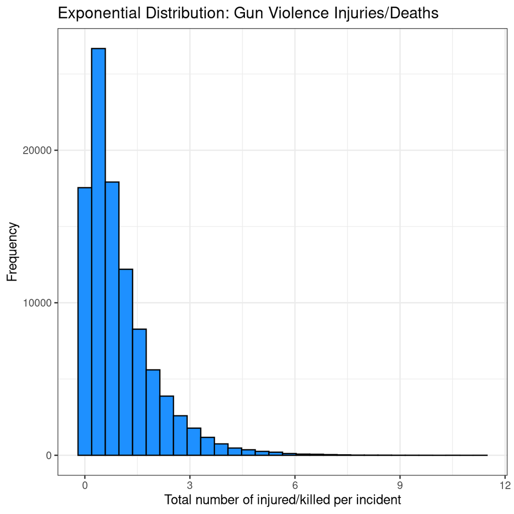

```r
shootings <- tibble(total = rexp(100000))

shootings %>% ggplot(aes(x = total)) +
  geom_histogram(color = "black", fill = "dodgerblue") +
  labs(title = "Exponential Distribution: Gun Violence Injuries/Deaths",
       x = "Total number of injured/killed per incident",
       y = "Frequency") +
  theme_bw()
```

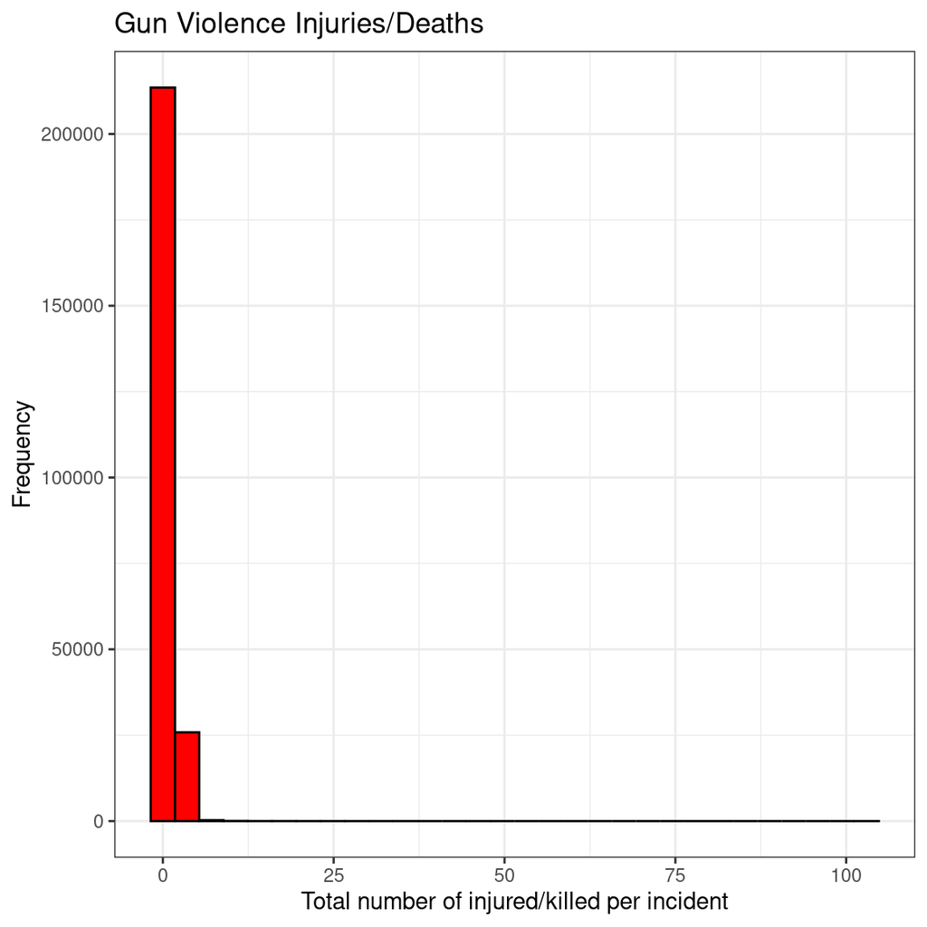

```r
gunViolence %>% ggplot(aes(x = n_totalKilledInjured)) +
  geom_histogram(color = "black", fill = "red") +
  labs(title = "Gun Violence Injuries/Deaths",
       x = "Total number of injured/killed per incident",
       y = "Frequency") +
  theme_bw()
```

```r
# Expected total number of injuries/deaths and 95% confidence interval
shootings %>% pull(total) %>% mean()
```

```
## [1] 1.000812
```

```r
lowerBound <- shootings %>% pull(total) %>% quantile(probs = 0.025)
upperBound <- shootings %>% pull(total) %>% quantile(probs = 0.975)
```

# Permutation Testing

```r
# Creating function to determine whether month falls in school calendar
isSchool <- function(month) {
  if(month < 6 || month > 8) {
    return("In school")
  }
  else {
    return("Not in school")
  }
}

# Adding variable to mass shooting data frame for school
massShooting <- massShooting %>% mutate(school = mapply(isSchool, month))
```

```r
# Two-sample t-test
tResult <- t.test(x = massShooting$n_totalKilledInjured[which(massShooting$school == "In school")],
                  y = massShooting$n_totalKilledInjured[which(massShooting$school == "Not in school")],
                  alternative = "less")
```

As the normality assumption for the 2 sample t-test is not met, we will use the permutation procedure to compare the 2 groups.

```r
n1 <- 10
n2 <- 10

# Generating all permutations
perms <- combn(1:(n1 + n2), m = n1)

# Calculating number of permutations
nperms <- choose(n1 + n2, n1)

# Instantiating vector for test statistics
permTs <- vector(length = nperms)

# Calculating t-test statistic for each permutation
for(p in 1:nperms) {
  permTs[p] <- t.test(x = massShooting$n_totalKilledInjured[perms[, p]],
                      y = massShooting$n_totalKilledInjured[-c(perms[, p])])$statistic
}
```

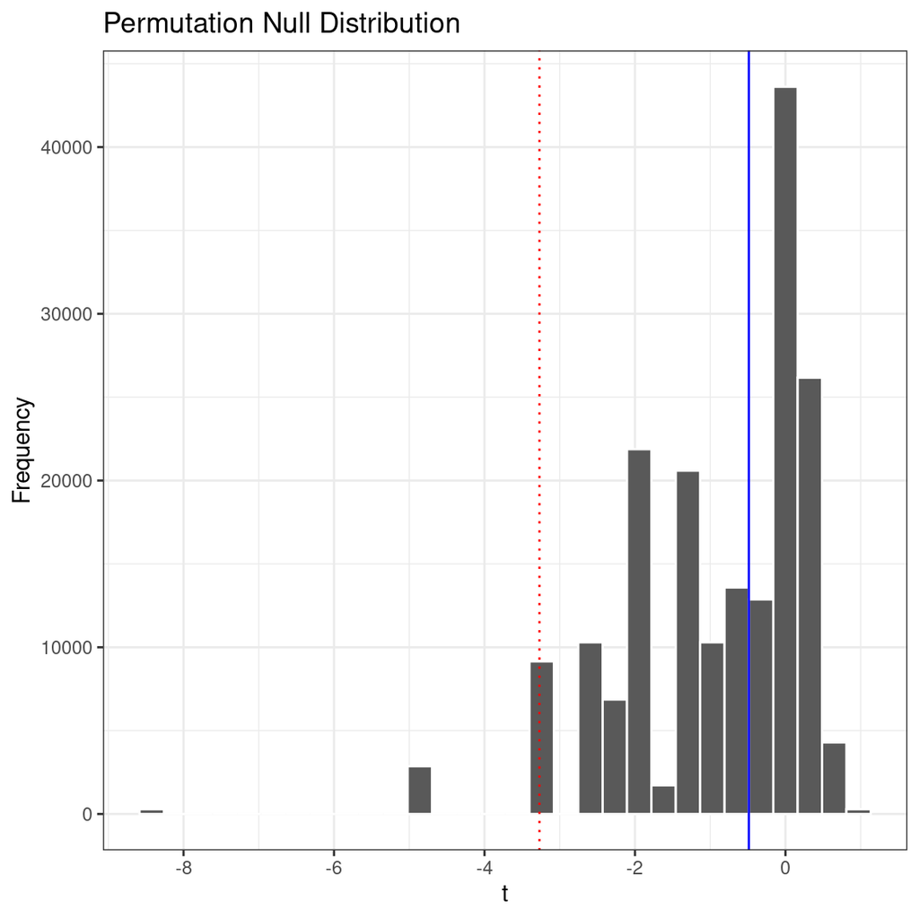

```r
# Creating a histogram for our null distribution
tibble(t = permTs) %>% ggplot(aes(x = t)) +
  geom_histogram(color = "white") +

# Vertical lines indicate where the 5th percentile is (a red dotted line), and where our observed test statistic is (solid blue line).
  geom_vline(xintercept = quantile(permTs, probs = 0.05),
             color = "red", linetype = "dotted") +
  geom_vline(xintercept = tResult$statistic,
             color = "blue", linetype = "solid") +
  labs(title = "Permutation Null Distribution",
       y = "Frequency") +
  theme_bw()
```

```r
permPvalue <- mean(permTs <= tResult$statistic)
```

Since the p-value of 0.5278638 is greater than 0.05, we fail to reject the null hypothesis; That is, we lack sufficient evidence to say that there is a difference in number of killed and injured from gun violence incidents during and out of the school year.

# Bootstrapping

```r
# Number of bootstrap samples
n <- 30
B <- 10000

# Instantiating matrix for bootstrap samples
boots <- matrix(NA, nrow = n, ncol = B)

# Sampling with replacement B times
for(b in 1:B) {
  boots[, b] <- gunViolence$n_totalKilledInjured[sample(1:n, size = n, replace = TRUE)]
}
```

```r
# Creating distribution of bootstrap medians
bootMedians <- vector(length = B)

for(b in 1:B) {
  bootMedians[b] <- median(boots[, b])
}
```

```r
# Estimating standard error of bootstrap medians
SEestimate <- sd(bootMedians)
SEestimate
```

```
## [1] 0.2237458
```

```r
# Nonparametric 95% confidence interval for population median
lowerBoundMed <- quantile(bootMedians, probs = 0.025)
upperBoundMed <- quantile(bootMedians, probs = 0.975)
```

Using bootstrapping, we can see that our estimate for the standard error of the population (All gun violence incidents) is 0.224 and we are 95% confident that the total number of individuals killed and injured in a gun violence incident is between 4 and 5. This is notably a much smaller interval than the one we found using the Monte Carlo method.

# Data Dictionary

```r
# Creating data dictionary.
dataDictionary <- tibble(Variable = colnames(gunViolence),
                         Description = c("gunviolencearchive.org ID for incident",
                                         "date of occurrence",
                                         "state",
                                         "city or county",
                                         "address where incident took place",
                                         "number of people killed",
                                         "number of people injured",
                                         "link to gunviolencearchive.org webpage containing details of incident",
                                         "link to online news story concerning incident",
                                         "ignore, always False",
                                         "Congressional district",
                                         "gun stolen or not, e.g. 'Unknown' or 'Stolen'",
                                         "description of gun type",
                                         "list of incident characteristics",
                                         "latitude of location",
                                         "description of location where incident took place",
                                         "longitude of location",
                                         "number of guns involved",
                                         "additional notes about the incident",
                                         "participant age",
                                         "participant description of age group, e.g. 'Adult 18+'",
                                         "participant gender being 'Male' or 'Female'",
                                         "participant name",
                                         "relationship of participant to other participants",
                                         "outcome, one of 'Arrested', 'Killed', 'Injured', or 'Unharmed'",
                                         "participant category being 'Victim' or 'Subject-Suspect'",
                                         "links to online news stories concerning incident",
                                         "state house district",
                                         "state senate district",
                                         "year incident occurred",
                                         "month incident occurred",
                                         "day incident occurred",
                                         "total number of people injured and killed",
                                         "result of incident, 'Injury', 'Injury and Death', 'Death', and 'No injury or death'"),
                         Type = map_chr(gunViolence, .f = function(x){typeof(x)[1]}),
                         Class = map_chr(gunViolence, .f = function(x){class(x)[1]}))
```

```r
flextable::flextable(dataDictionary, cwidth = 2)
```

| Variable | Description | Type | Class |
| --- | --- | --- | --- |
| incident_id | gunviolencearchive.org ID for incident | integer | integer |
| date | date of occurrence | character | character |
| state | state | character | character |
| city_or_county | city or county | character | character |
| address | address where incident took place | character | character |
| n_killed | number of people killed | integer | integer |
| n_injured | number of people injured | integer | integer |
| incident_url | link to gunviolencearchive.org webpage containing details of incident | character | character |
| source_url | link to online news story concerning incident | character | character |
| incident_url_fields_missing | ignore, always False | character | character |
| congressional_district | Congressional district | integer | integer |
| gun_stolen | gun stolen or not, e.g. 'Unknown' or 'Stolen' | character | character |
| gun_type | description of gun type | character | character |
| incident_characteristics | list of incident characteristics | character | character |
| latitude | latitude of location | double | numeric |
| location_description | description of location where incident took place | character | character |
| longitude | longitude of location | double | numeric |
| n_guns_involved | number of guns involved | integer | integer |
| notes | additional notes about the incident | character | character |
| participant_age | participant age | character | character |
| participant_age_group | participant description of age group, e.g. 'Adult 18+' | character | character |
| participant_gender | participant gender being 'Male' or 'Female' | character | character |
| participant_name | participant name | character | character |
| participant_relationship | relationship of participant to other participants | character | character |
| participant_status | outcome, one of 'Arrested', 'Killed', 'Injured', or 'Unharmed' | character | character |
| participant_type | participant category being 'Victim' or 'Subject-Suspect' | character | character |
| sources | links to online news stories concerning incident | character | character |
| state_house_district | state house district | integer | integer |
| state_senate_district | state senate district | integer | integer |
| year | year incident occurred | double | numeric |
| month | month incident occurred | double | numeric |
| day | day incident occurred | double | numeric |
| n_totalKilledInjured | total number of people injured and killed | integer | integer |
| incidentResult | result of incident, 'Injury', 'Injury and Death', 'Death', and 'No injury or death' | character | character |